# MejbahAhammad_MidTermAssignment

## 🔥🔥 Cifer-10 Analysis 🔥🔥

## Create Usefull Notebook for Cifer-10 Datasets with the different Condition

## Name: Mejbah Ahammad

## Student ID: 22-92357-1

The `**CIFAR-10**` dataset *(Canadian Institute for Advanced Research, 10 classes)* is a subset of the Tiny Images dataset and consists of 60000 32x32 color images. The images are **labelled** with one of 10 mutually exclusive classes: airplane, automobile (but not truck or pickup truck), bird, cat, deer, dog, frog, horse, ship, and truck (but not pickup truck). There are 6000 images per class with 5000 training and 1000 testing images per class.

#### `The criteria for deciding whether an image belongs to a class were as follows:`

- The class name should be high on the list of likely answers to the question “What is in this picture?”
- The image should be photo-realistic. Labelers were instructed to reject line drawings.
- The image should contain only one prominent instance of the object to which the class refers. The object may be partially occluded or seen from an unusual viewpoint as long as its identity is still clear to the labeler.

Now, performing this assignment i have taken few necessary module for analysis the meta-data of the raw datasets. They are following:

Numpy Pandas Mapltolib Random OpenCV Keras TensorFlow Scikit-Learn

### `**Conclution**` and `**Result**`

Optimizers Name

Accuracy Plot

Loss Plot

### 1. Adam

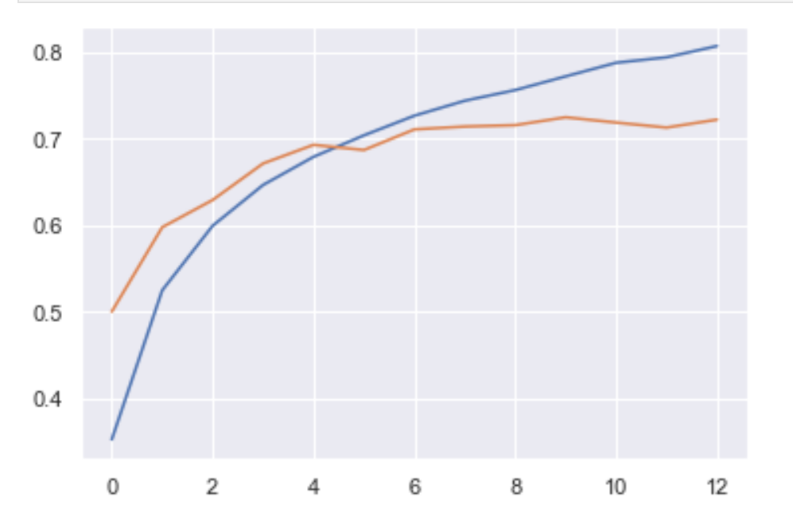

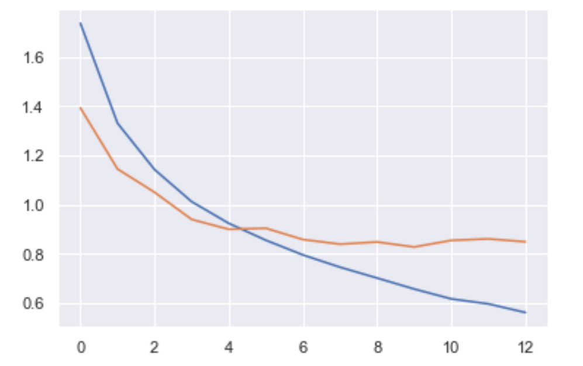

### 2. Adamax

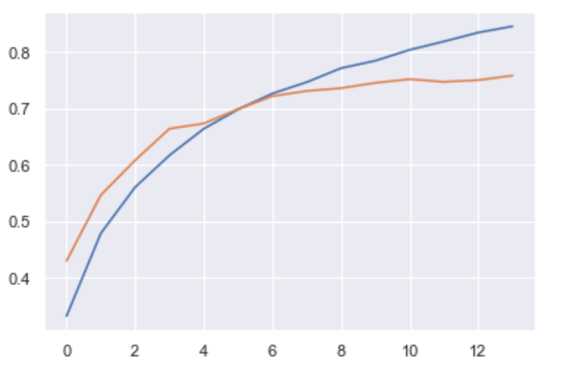

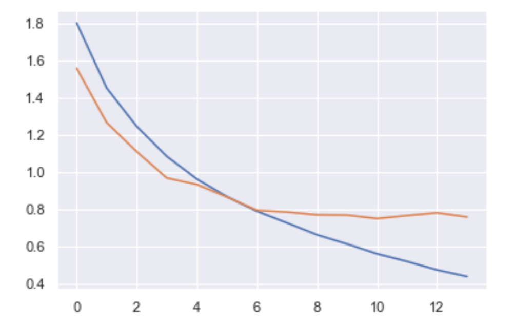

### 3. NAdam

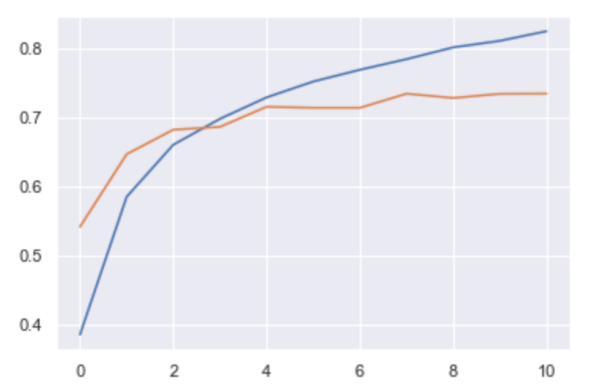

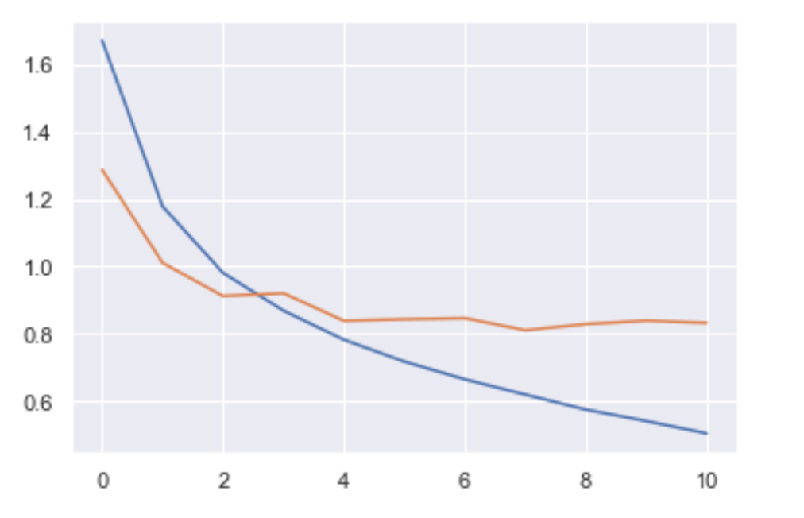

### 4. RMSprop

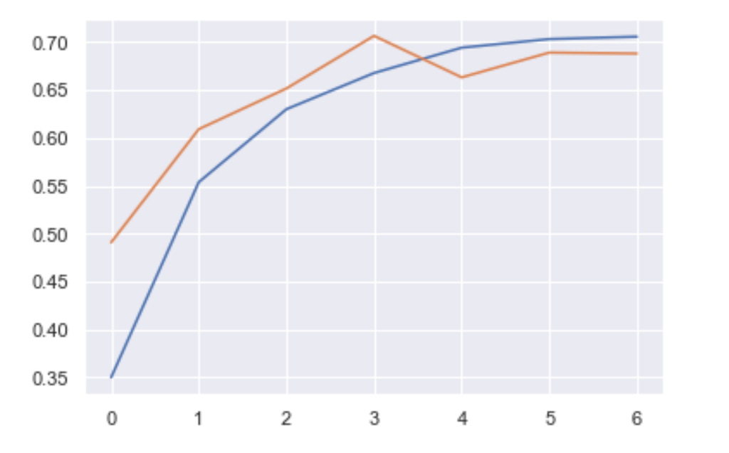

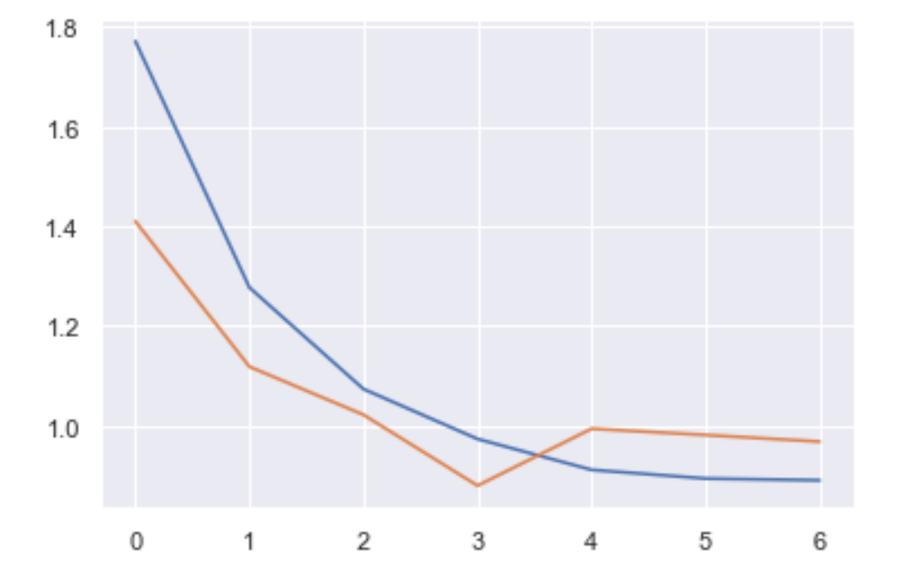

### 5. SGD

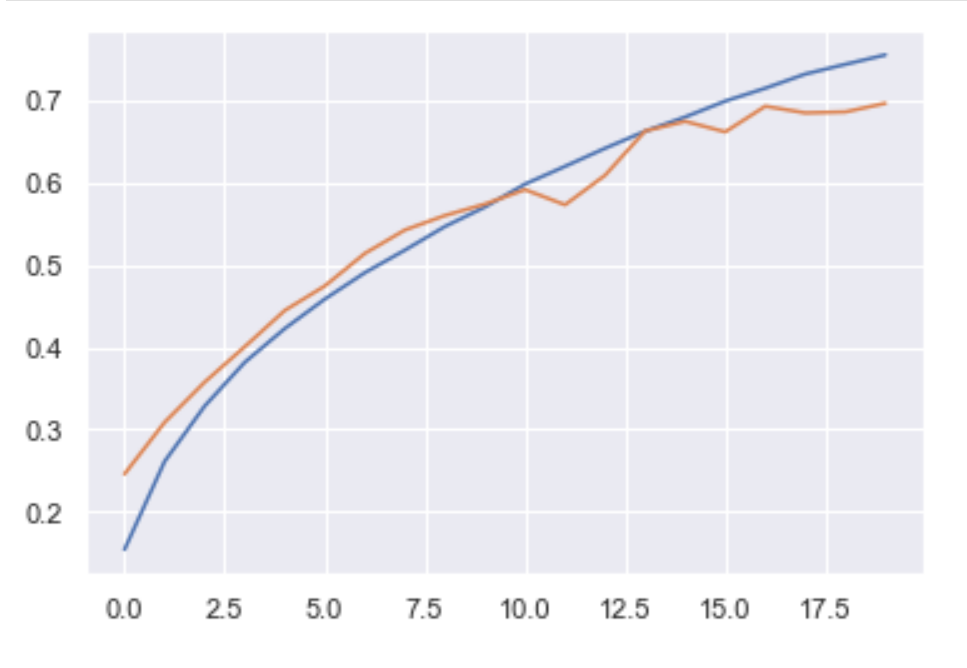

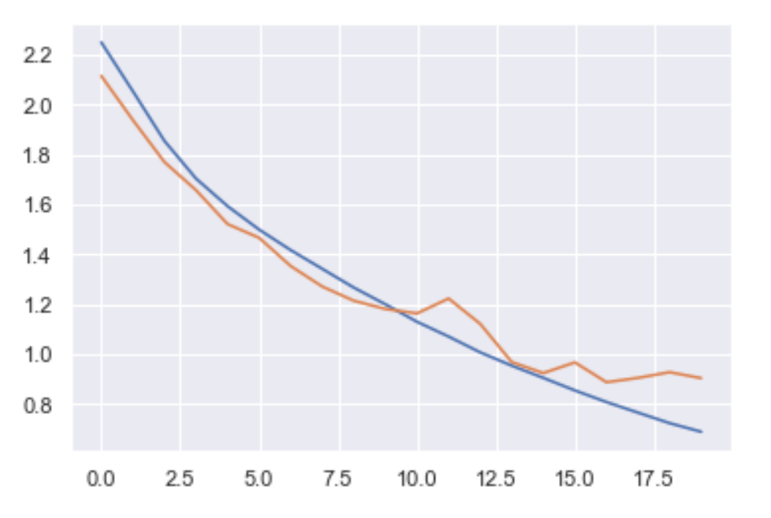

##### `From the above accuracy and Loss plot wen can ovserbe after the depth analysis that there was few fluctuations between the each optimizers results plot. We can reach and optimial condition if we use them we must consider few others parameter like:`

Padding Kernel Size Filters Strides and Others also

if we consider them as well as we can get different acceptable resluts we can choose best one from them.

#### `Here, I have attached`

Loss Val_loss Accuracy Val_accuracy To comepre them for getting best accuracy value and take whether my results contin overfitted condition or not.

[output not shown]

### `From the above accuracy and loss table we can assume that` `Adam`, `Nadam`, `Adamax` gives us better result compare with others. Bellow i have attached one sample visulatization which contains actual and predicted resluts.

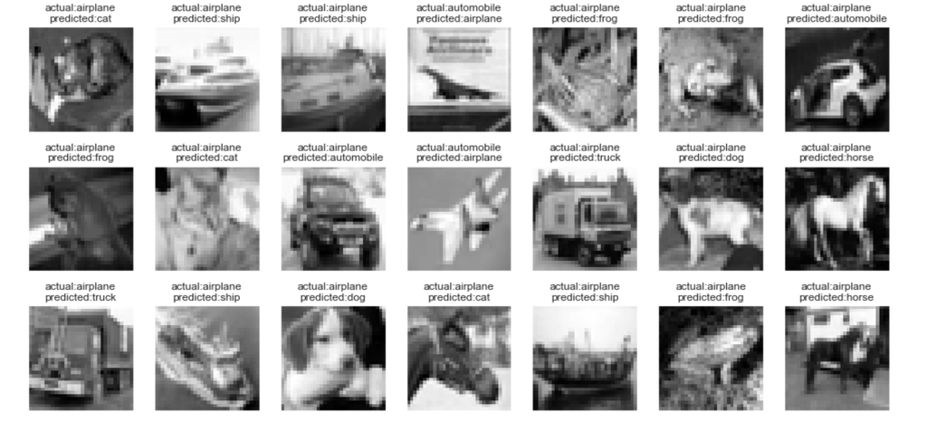